# Does International Collaboration Help IMDB Ratings? (focusing on Netflix)

### 4.0.1 Change in IMDb Ratings

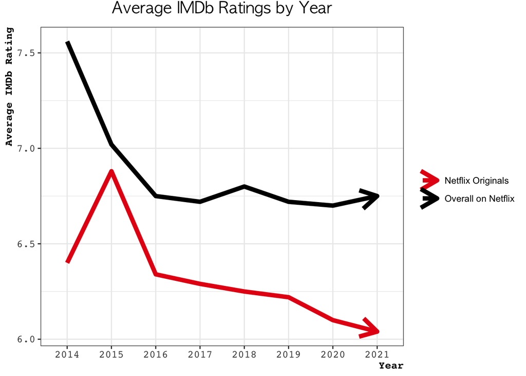

```r
imdb_average_ratings<-data.frame(year=c(2014,2015,2016,2017,2018,2019,2020,2021),
                                 group=c(rep("Netflix Originals",8),rep("Overall on Netflix",8)),
                                 ratings=c(c(6.4,6.88,6.34,6.29,6.25,6.22,6.10,6.04),c(7.56,7.02, 6.75,6.72,6.8,6.72,6.70,6.75)))

ggplot(data=imdb_average_ratings, aes(x=year,y=ratings,fill=group))+
  geom_line(aes(color=group),size=2,arrow=arrow())+scale_x_discrete(limits=c(seq(2014,2021,1)))+ scale_color_manual(values=c("#E50914","black"))+
  theme_bw() +
  labs(x="Year", y="Average IMDb Rating", title="Average IMDb Ratings by Year",color=NULL)+
  theme(plot.title = element_text(hjust = 0.5,vjust=2.5,size=15,face="bold",family = 'AppleGothic'),
        axis.text.x = element_text(size=10, family = 'mono'),
        axis.text.y = element_text(size=10, family = 'mono'),
        axis.title.x = element_text(size=10,face="bold", family = 'mono',hjust=1),
        axis.title.y = element_text(size=10, face="bold",family = 'mono',vjust=1,hjust=1))
```

# 5 Next steps

- need full history of data : Is it getting more diverse over time? –> don’t have full history to assess this (shows that are still on Netflix as of mid2021)
- change in number of countries involved
- other measure than IDMB ratings to assess user experience
- text mining review to figure out what is driving the decrease in average ratings
- missing data